# Lecture 3 PCA Live Demo: USArrests

STAT 24620 = STAT 32900, FINM 34700

Spring 2026

## Data and quick exploration

We perform PCA on the `USArrests` data set, which is part of the base `R` package. This data set contains statistics, in arrests per 100,000 residents for assault, murder, and rape in each of the 50 US states in 1973. Also given is the percent of the population living in urban areas.

The rows of the data set contain the 50 states, in alphabetical order.

```r
data(USArrests)
X <- USArrests
states <- row.names(X)
states
```

```
 [1] "Alabama"        "Alaska"         "Arizona"        "Arkansas"       "California"     "Colorado"       "Connecticut"
 [8] "Delaware"       "Florida"        "Georgia"        "Hawaii"         "Idaho"          "Illinois"       "Indiana"
[15] "Iowa"           "Kansas"         "Kentucky"       "Louisiana"      "Maine"          "Maryland"       "Massachusetts"
[22] "Michigan"       "Minnesota"      "Mississippi"    "Missouri"       "Montana"        "Nebraska"       "Nevada"
[29] "New Hampshire"  "New Jersey"     "New Mexico"     "New York"       "North Carolina" "North Dakota"   "Ohio"
[36] "Oklahoma"       "Oregon"         "Pennsylvania"   "Rhode Island"   "South Carolina" "South Dakota"   "Tennessee"
[43] "Texas"          "Utah"           "Vermont"        "Virginia"       "Washington"     "West Virginia"  "Wisconsin"
[50] "Wyoming"
```

The columns of the data set contain the four variables.

```r
summary(X)
```

```
     Murder         Assault       UrbanPop         Rape
 Min.   : 0.80   Min.   : 45   Min.   :32.0   Min.   : 7.3
 1st Qu.: 4.08   1st Qu.:109   1st Qu.:54.5   1st Qu.:15.1
 Median : 7.25   Median :159   Median :66.0   Median :20.1
 Mean   : 7.79   Mean   :171   Mean   :65.5   Mean   :21.2
 3rd Qu.:11.25   3rd Qu.:249   3rd Qu.:77.8   3rd Qu.:26.2
 Max.   :17.40   Max.   :337   Max.   :91.0   Max.   :46.0
```

## Visual exploration

We first briefly examine the data. Some variables are highly correlated.

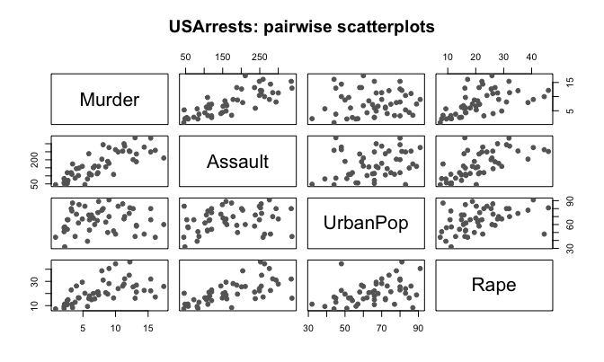

```r
pairs(X, pch = 19, col = "gray40", main = "USArrests: pairwise scatterplots")
```

The variables also have vastly different means and variances. We see that there are on average three times as many rapes as murders, and more than eight times as many assaults as rapes. The `UrbanPop` variable measures the percentage of the population in each state living in an urban area, which is not a comparable number to the number of rapes in each state per 100,000 individuals.

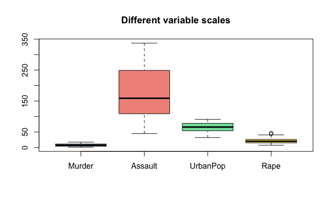

```r
boxplot(X, col = c("#7FB3D5", "#F1948A", "#82E0AA", "#F7DC6F"),
        main = "Different variable scales")
```

## PCA: no scaling vs scaling

We now perform principal components analysis using the `prcomp()` function, which is one of several functions in `R` that perform PCA.

By default, the `prcomp()` function centers the variables to have mean zero (we here add `center = TRUE` to explicitly confirm centering). By using the option `scale = TRUE`, we scale the variables to have standard deviation one. The output from `prcomp()` contains a number of useful quantities.

```r
pca_cov <- prcomp(X, center = TRUE, scale. = FALSE)
pca_cor <- prcomp(X, center = TRUE, scale. = TRUE)

names(pca_cov)
```

```
[1] "sdev"     "rotation" "center"   "scale"    "x"
```

The `center` and `scale` components correspond to the means and standard deviations of the variables that were used for scaling prior to implementing PCA.

```r
pca_cor$center
```

```
  Murder  Assault UrbanPop     Rape
   7.788  170.760   65.540   21.232
```

```r
pca_cor$scale
```

```
  Murder  Assault UrbanPop     Rape
   4.356   83.338   14.475    9.366
```

The `rotation` matrix provides the principal component loadings; each column of `pca$rotation` contains the corresponding principal component loading vector. Recall that the principal components are only unique up to a sign change.

```r
pca_cor$rotation
```

```
             PC1     PC2     PC3      PC4
Murder   -0.5359 -0.4182  0.3412  0.64923
Assault  -0.5832 -0.1880  0.2681 -0.74341
UrbanPop -0.2782  0.8728  0.3780  0.13388
Rape     -0.5434  0.1673 -0.8178  0.08902
```

If we failed to scale the variables before performing PCA, then most of the principal components that we observed would be driven by the `Assault` variable, since it has by far the largest mean and variance. Thus, it is important to standardize the variables to have mean zero and standard deviation one before performing PCA.

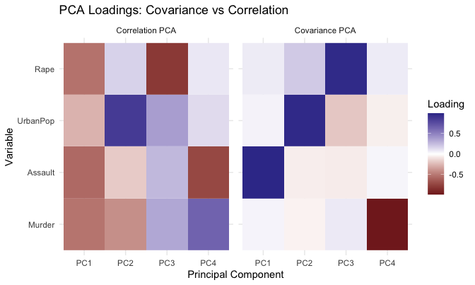

```r
library(ggplot2)
library(reshape2)
library(patchwork)

# choose number of PCs

# prepare function
make_df <- function(pca, label) {
  loadings <- pca$rotation
  df <- melt(loadings)
  colnames(df) <- c("Variable", "PC", "Loading")
  df$Method <- label
  df
}

df_cov <- make_df(pca_cov, "Covariance PCA")
df_cor <- make_df(pca_cor, "Correlation PCA")

df_all <- rbind(df_cov, df_cor)

# keep ordering
df_all$Variable <- factor(df_all$Variable,
                         levels = rownames(pca_cov$rotation))

# plot
p <- ggplot(df_all, aes(x = PC, y = Variable, fill = Loading)) +
  geom_tile() +
  scale_fill_gradient2(midpoint = 0) +
  facet_wrap(~Method, nrow = 1) +
  theme_minimal() +
  labs(title = "PCA Loadings: Covariance vs Correlation",
       x = "Principal Component",
       y = "Variable")

p
```

## Scree plots (side-by-side)

The `prcomp()` function also outputs the standard deviation of each principal component. On the `USArrests` data set, we can access these standard deviations as follows:

```r
pca_cor$sdev
```

```
[1] 1.5749 0.9949 0.5971 0.4164
```

The variance explained by each principal component is obtained by squaring these. The scree plot shows these variances. We see below that without scaling, most of the variability is explained by the first principal component, which is essentially the `Aasult` variable.

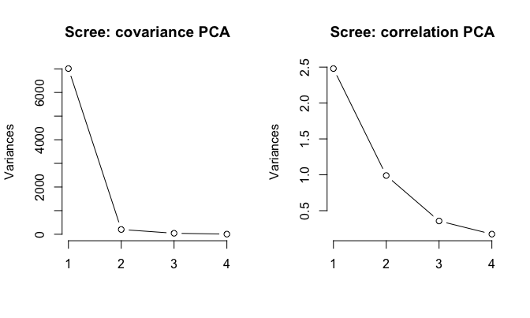

```r
par(mfrow = c(1, 2))
screeplot(pca_cov, type = "l", main = "Scree: covariance PCA")
screeplot(pca_cor, type = "l", main = "Scree: correlation PCA")
```

## Explained variance and cumulative PVE

```r
pve_cov <- (pca_cov$sdev^2) / sum(pca_cov$sdev^2)
pve_cor <- (pca_cor$sdev^2) / sum(pca_cor$sdev^2)

pve_cor
```

```
[1] 0.62006 0.24744 0.08914 0.04336
```

```r
par(mfrow = c(1, 2))

plot(cumsum(pve_cov), type = "b", pch = 19,
     xlab = "Principal Component",
     ylab = "Cumulative PVE",
     main = "Cumulative PVE (Covariance PCA)",
     ylim = c(0, 1))
abline(h = 0.8, col = "red", lty = 2)
```

```r
abline(h = 0.9, col = "blue", lty = 2)

plot(cumsum(pve_cor), type = "b", pch = 19,
     xlab = "Principal Component",
     ylab = "Cumulative PVE",
     main = "Cumulative PVE (Correlation PCA)",
     ylim = c(0, 1))
```

```r
abline(h = 0.8, col = "red", lty = 2)
abline(h = 0.9, col = "blue", lty = 2)
```

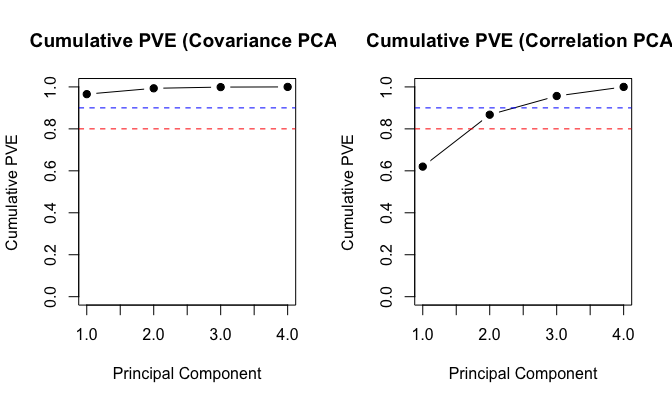

```r
par(mfrow = c(1, 1))
```

After scaling, we see that the first principal component explains $62.0 \%$ of the variance in the data, the next principal component explains $24.7 \%$ of the variance, and so forth.

## Number of PCs: Kaiser rule and parallel analysis (scaled PCA)

```r
# Kaiser rule: keep eigenvalues > 1 for correlation-based PCA
screeplot(pca_cor, type = "l", main = "Scree: correlation PCA")
abline(h = 1, col = "red", lty = 2)
```

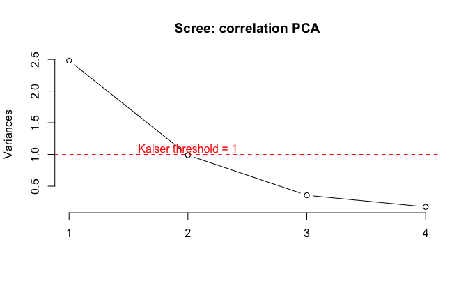

```r
## Optional: annotate
text(2, 1.1, "Kaiser threshold = 1", col = "red")
```

```r
# Parallel analysis
set.seed(24620)
B <- 500
n <- nrow(X)
p <- ncol(X)
eig <- pca_cor$sdev^2

rand_eigs <- replicate(B, {
  X_rand <- matrix(rnorm(n * p), nrow = n, ncol = p)
  eigen(cor(X_rand), symmetric = TRUE, only.values = TRUE)$values
})

rand_mean <- rowMeans(rand_eigs)
rand_95 <- apply(rand_eigs, 1, quantile, probs = 0.95)

pa_cutoff <- apply(rand_eigs, 1, quantile, probs = 0.95)

plot(eig, type = "b", pch = 19,
     xlab = "Principal Component",
     ylab = "Eigenvalue",
     main = "Parallel Analysis")
lines(rand_mean, type = "b", pch = 17, lty = 1, col = 2)
```

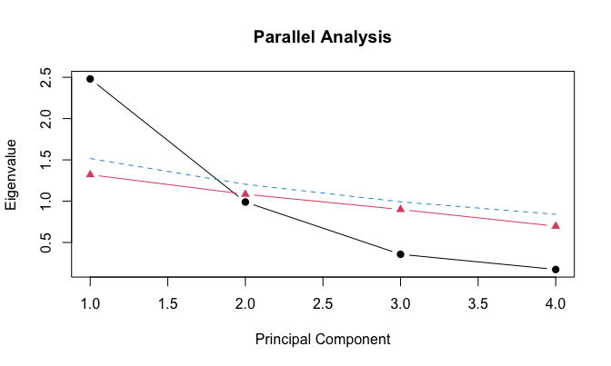

```r
lines(rand_95, lty = 2, col = 4)
```

- Kaiser suggests keeping `1` PC.
- Parallel analysis (95% baseline) also suggests keeping `1` PC.

## Loadings interpretation (scaled PCA)

```r
round(pca_cor$rotation[, 1:2], 3)
```

```
            PC1    PC2
Murder   -0.536 -0.418
Assault  -0.583 -0.188
UrbanPop -0.278  0.873
Rape     -0.543  0.167
```

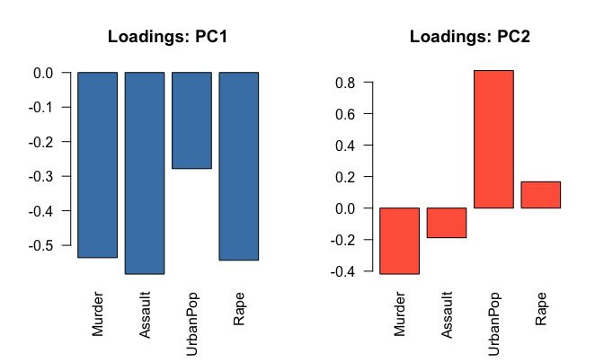

```r
par(mfrow = c(1, 2))
barplot(pca_cor$rotation[, 1], las = 2, main = "Loadings: PC1", col = "steelblue")
barplot(pca_cor$rotation[, 2], las = 2, main = "Loadings: PC2", col = "tomato")
```

- PC1 represents overall criminal level.
- PC2 contrasts urbanization with violent crime, especially murder.

## Score map (states in first two PCs)

The score matrix is stored in `pca$x`. The $k$th column is the $k$th principal component score vector.

```r
scores <- pca_cor$x[, 1:2]
plot(scores, type = "n", xlab = "PC1", ylab = "PC2",
     main = "USArrests states projected to (PC1, PC2)")
text(scores, labels = rownames(X), cex = 0.65, col = "gray30")
```

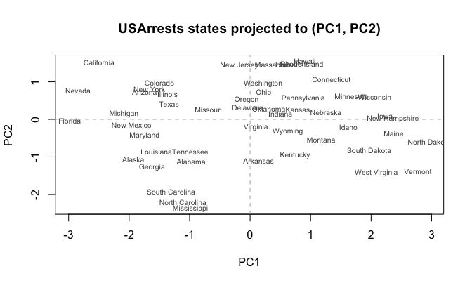

```r
abline(h = 0, v = 0, lty = 2, col = "gray70")
```

## Score map + loadings

We can have a more informative visualization by adding the loading directions

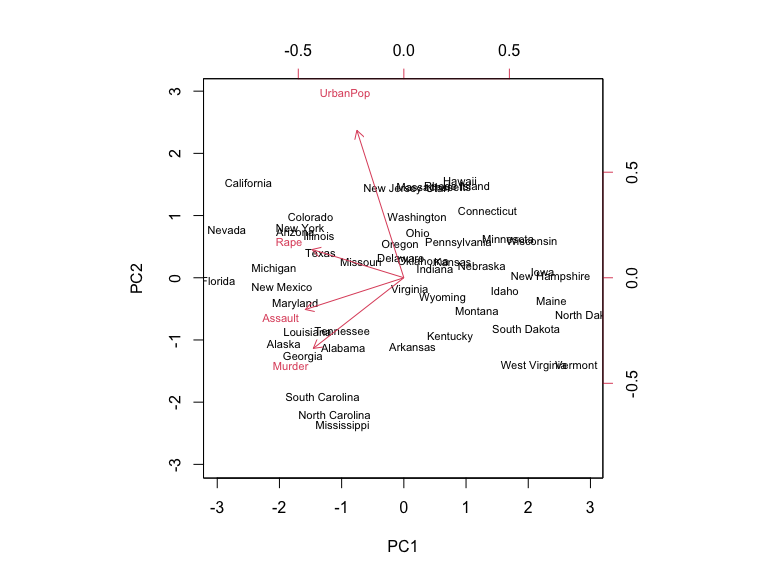

```r
biplot(pca_cor, scale = 0, cex = 0.7)
```

- PC1 represents overall criminal level, states on the left have high criminal rates overall.
- PC2 contrasts urbanization with violent crime: states at the top are more urban, while those at the bottom tend to have higher murder rates relative to their overall crime profile.

## Orthogonality check

```r
round(cov(pca_cor$x), 3)
```

```
     PC1  PC2   PC3   PC4
PC1 2.48 0.00 0.000 0.000
PC2 0.00 0.99 0.000 0.000
PC3 0.00 0.00 0.357 0.000
PC4 0.00 0.00 0.000 0.173
```

## Wrap-up

- Scaling matters here because variable magnitudes are very different.
- Use multiple criteria to choose PCs (scree/PVE + Kaiser + parallel analysis).
- Interpret loadings (variables) together with score map (states).